# PShaji_Assignment16

Priya Shaji

12/7/2019

**Problem 1**

**Using R, generate a random variable X that has 10,000 random uniform numbers from 1 to N, where N can be any number of your choosing greater than or equal to 6. Then generate a random variable Y that has 10,000 random normal numbers with a mean of μ=σ=(N+1)/2.**

**Answer**

```r
set.seed(293823)
n <- 10000
N <- 20
X <- round(runif(n, 1, N))
Y <- round(rnorm(n, mean = (N+1)/2, sd = (N+1)/2))
x <- median(X)
y <- as.numeric(quantile(Y, probs=c(.25)))
```

Probability. Calculate as a minimum the below probabilities a through c. Assume the small letter “x” is estimated as the median of the X variable, and the small letter “y” is estimated as the 1st quartile of the Y variable. Interpret the meaning of all probabilities.

5 points a. P(X>x | X>y) b. P(X>x, Y>y) c. P(X<x | X>y)

**Answer a)**

1. P(X>x|X>y): Probability that X is greater than the median, given that X is greater than the 1st quartile of Y.

```r
P_X_gt_y <- length(X[X>y]) / n
numerator <- length(X[X>max(x,y)]) / n
numerator
```

```
## [1] 0.4488
```

```r
dnm <- P_X_gt_y
dnm
```

```
## [1] 0.8108
```

**Answer b)**

2. P(X>x,Y>y) Probability that X is greater than the median and that Y is greater than the 1st quartile.

```r
X_gt_x <- length(X[X>x])
X_le_x <- n - X_gt_x
Y_gt_y <- length(Y[Y>y])
Y_le_y <- n - Y_gt_y
P_X_gt_x <- X_gt_x / n
P_X_gt_x
```

```
## [1] 0.4488
```

```r
P_Y_gt_y <- Y_gt_y / n
P_Y_gt_y
```

```
## [1] 0.7247
```

**Answer c)**

3. P(X<x|X>y) Probability that X is less than the median, given that X is greater than the 1st quartile of Y.

```r
numerator <- length(X[(X < x) & (X > y)]) / n
numerator
```

```
## [1] 0.3086
```

```r
denominator <- P_X_gt_y
denominator
```

```
## [1] 0.8108
```

5 points. Investigate whether P(X>x and Y>y)=P(X>x)P(Y>y) by building a table and evaluating the marginal and joint probabilities.

**Answer**

Cartesian product of data frame

```r
d <- data.frame(X = rep(X, n),Y = rep(Y, n))
X_gt_x_and_Y_gt_y <- nrow(d[d$X>x & d$Y>y,]) / n
X_gt_x_and_Y_le_y <- nrow(d[d$X>x & d$Y<=y,]) / n

sum1<-X_gt_x_and_Y_gt_y+X_gt_x_and_Y_le_y

X_le_x_and_Y_gt_y <- nrow(d[d$X<=x & d$Y>y,]) / n
X_le_x_and_Y_le_y <- nrow(d[d$X<=x & d$Y<=y,]) / n
```

**Table of Counts**

```r
sum2<- X_le_x_and_Y_gt_y+X_le_x_and_Y_le_y

a <- c(X_gt_x_and_Y_gt_y, X_gt_x_and_Y_le_y, sum1)
b <- c(X_le_x_and_Y_gt_y, X_le_x_and_Y_le_y, sum2)
c<- c(X_gt_x_and_Y_gt_y+X_le_x_and_Y_gt_y,X_gt_x_and_Y_le_y+X_le_x_and_Y_le_y,sum1+sum2)

tbl <- data.frame(rbind(a, b,c))

names(tbl) <- c("Y>y", "Y<=y", "Total")
row.names(tbl) <- c("X>x", "X<=x", "Total")


tbl
```

|  | Y>y | Y<=y | Total |
| --- | --- | --- | --- |
| X>x | 3249 | 1239 | 4488 |
| X<=x | 3998 | 1514 | 5512 |
| Total | 7247 | 2753 | 10000 |

**Joint Probabilities**

```r
sum1<-X_gt_x_and_Y_gt_y+X_gt_x_and_Y_le_y
sum2<- X_le_x_and_Y_gt_y+X_le_x_and_Y_le_y

a <- c(X_gt_x_and_Y_gt_y/(sum1+sum2), X_gt_x_and_Y_le_y/(sum1+sum2))
b <- c(X_le_x_and_Y_gt_y/(sum1+sum2), X_le_x_and_Y_le_y/(sum1+sum2))


tbl_2 <- data.frame(rbind(a, b))

names(tbl_2) <- c("Y>y", "Y<=y")
row.names(tbl_2) <- c("X>x", "X<=x")


tbl_2
```

|  | Y>y | Y<=y |
| --- | --- | --- |
| X>x | 0.3249 | 0.1239 |
| X<=x | 0.3998 | 0.1514 |

**Marginal Probabilities**

PX=(X>x X≤x  
4488/10000 5512/10000) PY=(Y>y Y≤y  
7247/10000 2753/10000)

**Conclusion**

P(X>x and Y>y)≈P(X>x)P(Y>y)

P(X>x and Y>y) = 3249/10000 = 0.3249

P(X>x)P(Y>y) = 4488/10000⋅7247/10000=0.325

As we see here: P(X>x and Y>y)=P(X>x)P(Y>y) is true.

5 points. Check to see if independence holds by using Fisher’s Exact Test and the Chi Square Test. What is the difference between the two? Which is most appropriate?

**Fisher’s Exact Test**

If we start with the hypothesis that X and Y are independent, then, based on the above, we would expect the value for P(X>x,Y>y) to be 0.325. Our actual value is 0.3249. If the probability of obtaining a value higher than 0.3249 (i.e. deviating from the expected value) is small, then we would reject the hypothesis. Otherwise, hypothesis holds. To find such probability, we can use phyper function, in order to find the upper tail for the Hypergeometric Distribution, required for the Fisher’s Test.

```r
ph_x <- X_gt_x_and_Y_gt_y
ph_m <- X_gt_x_and_Y_gt_y + X_le_x_and_Y_gt_y
ph_n <- n - ph_m
ph_k <- X_gt_x_and_Y_gt_y + X_gt_x_and_Y_le_y
phpr <- phyper(ph_x, ph_m, ph_n, ph_k, lower.tail = FALSE)
phpr
```

```
## [1] 0.5530168
```

The above probability value, 0.55, is large and therefore, based on this test, the hypothesis cannot be rejected and therefore, the variables X and Y are independent.

**Chi-Squared Test**

The “chi-squared”, $x^2$ value for the above observations can be computed as follows:

$x^2=\sum_{i=1}^{4}(Oi−Ei)^2/Ei$,where Oi - observed value and Ei - expected value Based on the Table of Counts above, we have,

```r
O1 <- X_gt_x_and_Y_gt_y
O2 <- X_gt_x_and_Y_le_y
O3 <- X_le_x_and_Y_gt_y
O4 <- X_le_x_and_Y_le_y

E1 <- round(X_gt_x * Y_gt_y / n)
E2 <- round(X_gt_x * Y_le_y / n)
E3 <- round(X_le_x * Y_gt_y / n)
E4 <- round(X_le_x * Y_le_y / n)
```

Thus, $x^2$ is calculated as follows:

```r
chi_sq <- round(
(O1 - E1)^2/E1 +
(O2 - E2)^2/E2 +
(O3 - E3)^2/E3 +
(O4 - E4)^2/E4 ,
4)
```

Degrees of freedom, df, is computed as follows:

$df=(R−1)×(C−1)=(2−1)(2−1)=1$

where R is the number of rows in the table and C is the number of columns.

Finding the p-value for the chi-squared distribution, will indicate whether or not we should reject our hypothesis. If p-value is small (less than 0.05 ), then we reject our hypothesis that variables X and Y are independent. To compute the p-value, pchisq function can be used as follows:

```r
p_chi_sq <- pchisq(chi_sq, df=1, lower.tail = FALSE)
p_chi_sq
```

```
## [1] 0.8926851
```

The p-value=0.89, is large and therefore, based on this test, the hypothesis cannot be rejected and therefore, the variables X and Y are independent.

Both, Fisher’s Exact Test and Chi-Squared Test proved equally effective in testing the hypothesis in this case.

**Problem 2**

You are to register for Kaggle.com (free) and compete in the House Prices: Advanced Regression Techniques competition. https://www.kaggle.com/c/house-prices-advanced-regression-techniques . I want you to do the following.

5 points. Descriptive and Inferential Statistics. Provide univariate descriptive statistics and appropriate plots for the training data set. Provide a scatterplot matrix for at least two of the independent variables and the dependent variable. Derive a correlation matrix for any three quantitative variables in the dataset. Test the hypotheses that the correlations between each pairwise set of variables is 0 and provide an 80% confidence interval. Discuss the meaning of your analysis. Would you be worried about familywise error? Why or why not?

**Answer**

GrLivArea: Above grade (ground) living area square feet YearBuilt: Original construction date BedroomAbvGr: Bedrooms above grade (does NOT include basement bedrooms)

```r
df.train <- read.csv("https://raw.githubusercontent.com/PriyaShaji/Data605/master/week%2016/train.csv")

summary(df.train$GrLivArea)
```

```
##    Min. 1st Qu.  Median    Mean 3rd Qu.    Max.
##     334    1130    1464    1515    1777    5642
```

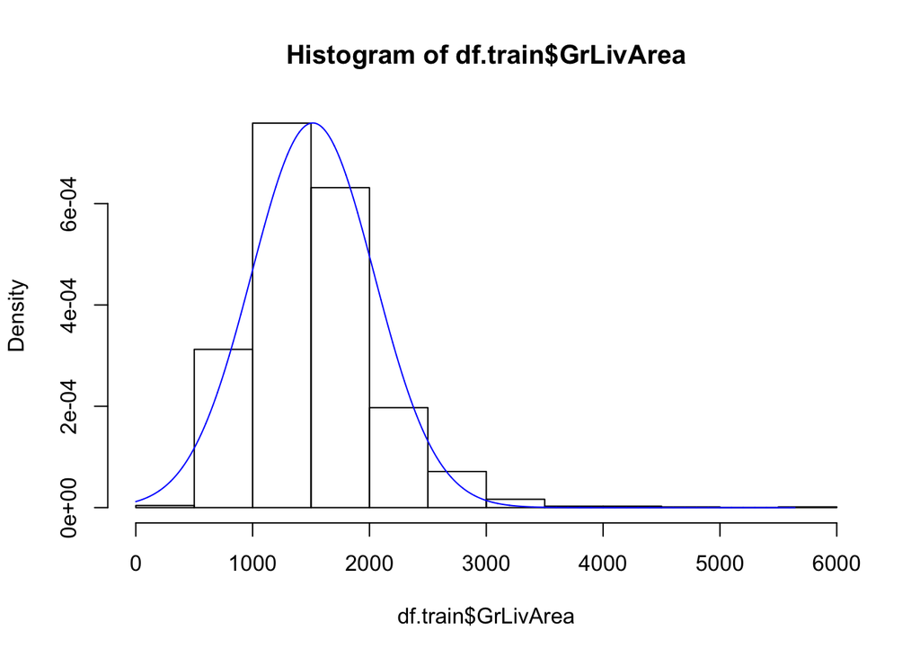

```r
a_sd <- sd(df.train$GrLivArea)
a_mn <- mean(df.train$GrLivArea)
a_max <- max(df.train$GrLivArea)
a_min <- min(df.train$GrLivArea)
a_x <- 0:a_max
a_y <- dnorm(x=a_x, mean=a_mn, sd=a_sd)
hist(df.train$GrLivArea, probability = T)
lines(x=a_x, y=a_y, col='blue')
```

```r
summary(df.train$SalePrice)
```

```
##    Min. 1st Qu.  Median    Mean 3rd Qu.    Max.
##   34900  129975  163000  180921  214000  755000
```

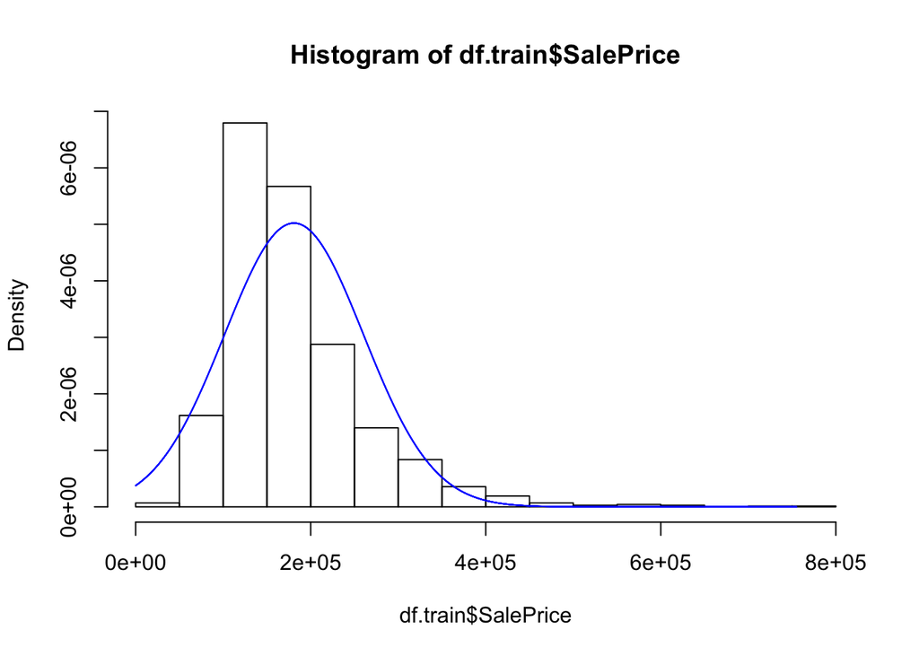

```r
a_sd <- sd(df.train$SalePrice)
a_mn <- mean(df.train$SalePrice)
a_max <- max(df.train$SalePrice)
a_min <- min(df.train$SalePrice)
a_x <- 0:a_max
a_y <- dnorm(x=a_x, mean=a_mn, sd=a_sd)
hist(df.train$SalePrice, probability = T)
lines(x=a_x, y=a_y, col='blue')
```

Scatter Plot with Regression Line

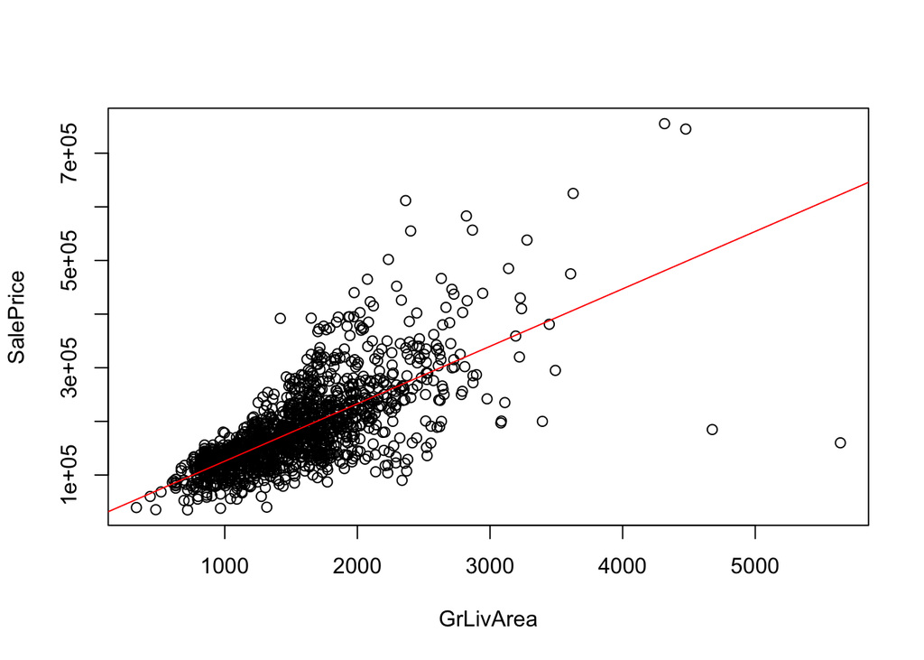

```r
plot(SalePrice~GrLivArea, data = df.train)
a_lm <- lm(SalePrice~GrLivArea, data = df.train)
abline(a_lm, col = 'red')
```

Residual Analysis

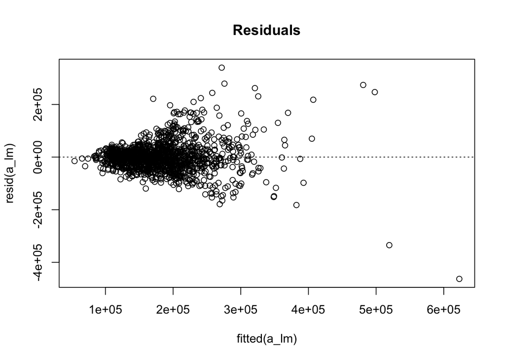

```r
plot(fitted(a_lm), resid(a_lm), main = "Residuals")
abline(h = 0, lty = 3)
```

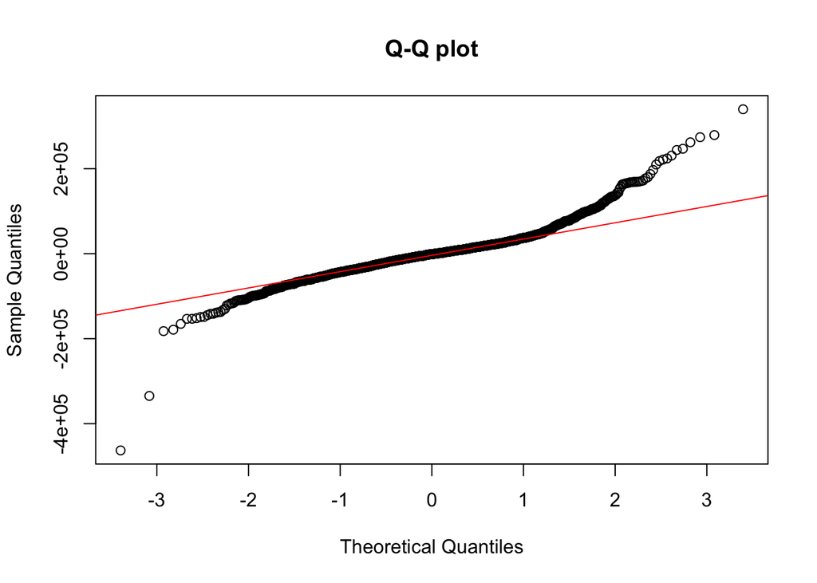

```r
qqnorm(a_lm$residuals, main = "Q-Q plot")
qqline(a_lm$residuals, col = 'red')
```

The Scatterplot Matrix below shows 3 independent variables (GrLivArea, BedroomAbvGr, YearBuilt) and the dependent variable (SalePrice).

Using “Pairs” function below

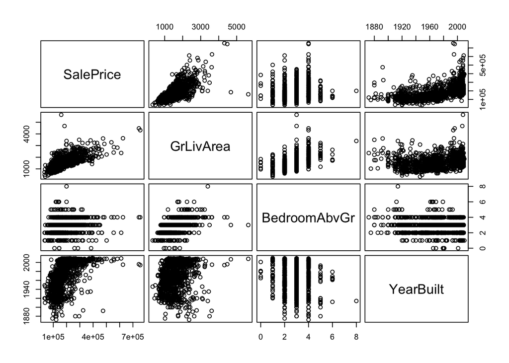

```r
pairs(~SalePrice+GrLivArea+BedroomAbvGr+YearBuilt, data = df.train, gap = 0.5)
```

Below is the Correlation Matrix for the same set of variables.

```r
m_a <- cor(df.train[,c("SalePrice", "GrLivArea", "BedroomAbvGr", "YearBuilt")])
m_a
```

```
##              SalePrice GrLivArea BedroomAbvGr   YearBuilt
## SalePrice    1.0000000 0.7086245   0.16821315  0.52289733
## GrLivArea    0.7086245 1.0000000   0.52126951  0.19900971
## BedroomAbvGr 0.1682132 0.5212695   1.00000000 -0.07065122
## YearBuilt    0.5228973 0.1990097  -0.07065122  1.00000000
```

Performing Pairwise correlation Testing indicated that correlation between each pairwise set of variables is not 0. (using the 80% confidence interval)

```r
cor.test(~GrLivArea+YearBuilt, data = df.train, conf.level = 0.8)
```

```
##
##  Pearson's product-moment correlation
##
## data:  GrLivArea and YearBuilt
## t = 7.754, df = 1458, p-value = 1.66e-14
## alternative hypothesis: true correlation is not equal to 0
## 80 percent confidence interval:
##  0.1665605 0.2310283
## sample estimates:
##       cor
## 0.1990097
```

```r
cor.test(~BedroomAbvGr+YearBuilt, data = df.train, conf.level = 0.8)
```

```
##
##  Pearson's product-moment correlation
##
## data:  BedroomAbvGr and YearBuilt
## t = -2.7045, df = 1458, p-value = 0.006921
## alternative hypothesis: true correlation is not equal to 0
## 80 percent confidence interval:
##  -0.10396633 -0.03717773
## sample estimates:
##         cor
## -0.07065122
```

```r
cor.test(~BedroomAbvGr+GrLivArea, data = df.train, conf.level = 0.8)
```

```
##
##  Pearson's product-moment correlation
##
## data:  BedroomAbvGr and GrLivArea
## t = 23.323, df = 1458, p-value < 2.2e-16
## alternative hypothesis: true correlation is not equal to 0
## 80 percent confidence interval:
##  0.4963921 0.5452915
## sample estimates:
##       cor
## 0.5212695
```

Despite the above hypothesis rejections, I would be worried about the familywise error, given that there are a lot of observations and the likelihood of the error is almost guaranteed.

5 points. Linear Algebra and Correlation. Invert your correlation matrix from above. (This is known as the precision matrix and contains variance inflation factors on the diagonal.) Multiply the correlation matrix by the precision matrix, and then multiply the precision matrix by the correlation matrix. Conduct LU decomposition on the matrix.

**Answer**

```r
m_b <- solve(m_a)
m_b
```

```
##               SalePrice  GrLivArea BedroomAbvGr   YearBuilt
## SalePrice     3.1146672 -2.2892182   0.58943471 -1.13143025
## GrLivArea    -2.2892182  3.1697849  -1.23338893  0.47906764
## BedroomAbvGr  0.5894347 -1.2333889   1.54706581  0.04654462
## YearBuilt    -1.1314302  0.4790676   0.04654462  1.49957118
```

```r
m_a %*% m_b
```

```
##                  SalePrice     GrLivArea BedroomAbvGr     YearBuilt
## SalePrice     1.000000e+00  0.000000e+00 2.081668e-17  1.110223e-16
## GrLivArea    -1.942890e-16  1.000000e+00 3.469447e-18  1.110223e-16
## BedroomAbvGr -1.387779e-17 -2.775558e-17 1.000000e+00 -1.387779e-17
## YearBuilt    -2.220446e-16 -2.220446e-16 0.000000e+00  1.000000e+00
```

```r
m_b %*% m_a
```

```
##                  SalePrice     GrLivArea  BedroomAbvGr     YearBuilt
## SalePrice     1.000000e+00 -6.383782e-16 -2.359224e-16 -2.220446e-16
## GrLivArea     4.996004e-16  1.000000e+00  1.942890e-16  0.000000e+00
## BedroomAbvGr -1.977585e-16 -2.168404e-16  1.000000e+00 -4.857226e-17
## YearBuilt     1.110223e-16  5.551115e-17 -2.775558e-17  1.000000e+00
```

To conduct LU decomposition on the matrix, I have written the lu_decomp function below

```r
lu_decomp <- function(m) {
  n <- ncol(m)
  U <- m[,]
  L <- matrix(nrow = n, ncol = n)
  L[1, 1] <- 1
  L[1, 2:n] <- 0

  for (j in seq(1, n - 1)) {
    for (i in  seq(j + 1, n)) {
      f <- U[i, j] / U[j, j]
      L[i, j] <- f
      L[i, j + 1] <- 1
      if (j + 1 < n) {
        L[i, (j + 2):n] <- 0
      }
      for (k in seq(j, n)) {
        U[i, k] <- U[i, k] - f * U[j, k]
      }
    }
  }

  result = list(L, U)
  names(result) <- c("L", "U")

  return(result)
}
```

LU Decomposition

```r
m_lu <- lu_decomp(m_b)
m_lu
```

```
## $L
##            [,1]       [,2]       [,3] [,4]
## [1,]  1.0000000  0.0000000 0.00000000    0
## [2,] -0.7349800  1.0000000 0.00000000    0
## [3,]  0.1892448 -0.5380153 1.00000000    0
## [4,] -0.3632588 -0.2370212 0.07065122    1
##
## $U
##              SalePrice     GrLivArea BedroomAbvGr   YearBuilt
## SalePrice     3.114667 -2.289218e+00    0.5894347 -1.13143025
## GrLivArea     0.000000  1.487255e+00   -0.8001662 -0.35251098
## BedroomAbvGr  0.000000  1.110223e-16    1.0050166  0.07100565
## YearBuilt     0.000000  0.000000e+00    0.0000000  1.00000000
```

Validating the decomposition by multiplying both halves of the matrix to get the original one.

```r
message("Validating the decomposition, by getting the original matrix")
```

```
## Validating the decomposition, by getting the original matrix
```

```r
m_lu$L %*% m_lu$U
```

```
##       SalePrice  GrLivArea BedroomAbvGr   YearBuilt
## [1,]  3.1146672 -2.2892182   0.58943471 -1.13143025
## [2,] -2.2892182  3.1697849  -1.23338893  0.47906764
## [3,]  0.5894347 -1.2333889   1.54706581  0.04654462
## [4,] -1.1314302  0.4790676   0.04654462  1.49957118
```

5 points. Calculus-Based Probability & Statistics. Many times, it makes sense to fit a closed form distribution to data. Select a variable in the Kaggle.com training dataset that is skewed to the right, shift it so that the minimum value is absolutely above zero if necessary. Then load the MASS package and run fitdistr to fit an exponential probability density function. (See https://stat.ethz.ch/R-manual/R-devel/library/MASS/html/fitdistr.html ). Find the optimal value of λ for this distribution, and then take 1000 samples from this exponential distribution using this value (e.g., rexp(1000, λ)). Plot a histogram and compare it with a histogram of your original variable. Using the exponential pdf, find the 5th and 95th percentiles using the cumulative distribution function (CDF). Also generate a 95% confidence interval from the empirical data, assuming normality. Finally, provide the empirical 5th percentile and 95th percentile of the data. Discuss.

**Answer**

```r
library(MASS)

hs_liv <- df.train$GrLivArea
fd_rate <- fitdistr(hs_liv, "exponential")
fd_rate
```

```
##        rate
##   6.598640e-04
##  (1.726943e-05)
```

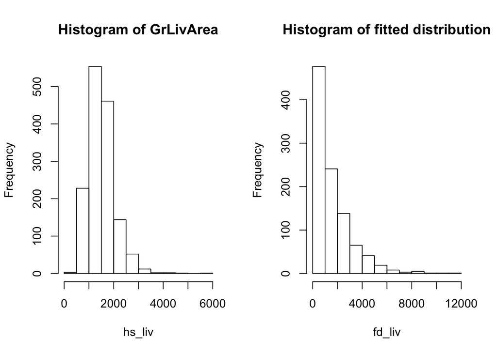

```r
fd_liv <- rexp(1000, rate = fd_rate$estimate)

par(mfrow = c(1, 2))
hist(hs_liv, main = "Histogram of GrLivArea")
hist(fd_liv, main = "Histogram of fitted distribution")
```

I selected GrLivArea variable which appears to be somewhat right-skewed. Fitting an “exponential” distribution, resulted in an optimal value of $λ=7×10^{−4}$

Find the 5th and 95th percentiles

```r
qexp(c(0.05, 0.95), rate = fd_rate$estimate)
```

```
## [1]   77.73313 4539.92351
```

```r
a_qn <- qnorm(c(0.05, 0.95), mean = mean(hs_liv), sd = sd(hs_liv))
a_qn
```

```
## [1]  651.1254 2379.8020
```

Provide the empirical 5th and 95th percentiles of the data

```r
quantile(ecdf(hs_liv), c(0.05, 0.95))
```

```
##     5%    95%
##  848.0 2466.1
```

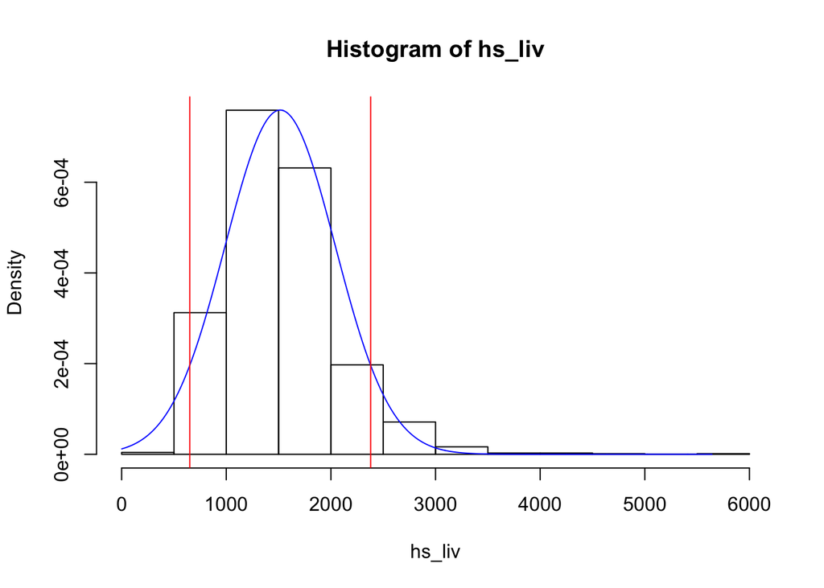

```r
a_x <- seq(1, max(hs_liv), length.out = length(hs_liv))
a_y <- dnorm(x = a_x, mean = mean(hs_liv), sd = sd(hs_liv))
hist(hs_liv, probability = T)
lines(x = a_x, y = a_y, col = 'blue')
abline(v = a_qn, col = 'red')
```

Even though, the data for the GrLivArea variable appeares to be right-skewed, the interval numbers and the plots above show that it is better described by a normal distribution rather than an exponential one.

10 points. Modeling. Build some type of multiple regression model and submit your model to the competition board. Provide your complete model summary and results with analysis. Report your Kaggle.com user name and score.

**Answer**

```r
trn <- df.train[,(names(df.train) %in% c("MSSubClass", "MSZoning", "LotFrontage", "LotArea", "LotShape", "LandContour", "LotConfig", "LandSlope", "Neighborhood", "Condition1", "Condition2", "BldgType", "HouseStyle", "OverallQual", "OverallCond", "Exterior1st", "Exterior2nd", "ExterQual", "ExterCond", "Foundation", "HeatingQC", "CentralAir", "GrLivArea", "TotRmsAbvGrd", "GarageArea"))]

# Impute missing data
mean_LotFrontage <- as.integer(summary(trn$LotFrontage)["Mean"])
trn$LotFrontage <- replace(trn$LotFrontage, is.na(trn$LotFrontage), mean_LotFrontage)

# Derive/Calculate additional features
trn$AgeSold <- df.train$YrSold - df.train$YearBuilt + 1
trn$AgeRemod <- df.train$YrSold - df.train$YearRemodAdd + 1

# Rescale numeric data
# Use Standardization: Subtract the mean and divide by variance
#   This way the features are centered around zero and have variance one
standardScaler <- function(x) {
  m <- mean(x)
  s <- sd(x)
  return ((x - m) / s)
}
trn$GrLivArea <- standardScaler(trn$GrLivArea)
trn$GarageArea <- standardScaler(trn$GarageArea)
trn$AgeSold <- standardScaler(trn$AgeSold)
trn$AgeRemod <- standardScaler(trn$AgeRemod)
```

```r
trn$SalePrice <- df.train$SalePrice

hs.lm <- lm(SalePrice~MSSubClass +  MSZoning   +  LotFrontage + LotArea   +  LotShape   +  LandContour + LotConfig  +  LandSlope  +  Neighborhood+ Condition1 +  Condition2 +  BldgType    +
+ HouseStyle +  OverallQual+  OverallCond + Exterior1st+  Exterior2nd+  ExterQual   +
+ ExterCond  +  Foundation +  HeatingQC   + CentralAir +  GrLivArea  +  TotRmsAbvGrd
+ GarageArea +  AgeSold    +  AgeRemod, data = trn)

summary(hs.lm)
```

```
##
## Call:
## lm(formula = SalePrice ~ MSSubClass + MSZoning + LotFrontage +
##     LotArea + LotShape + LandContour + LotConfig + LandSlope +
##     Neighborhood + Condition1 + Condition2 + BldgType + +HouseStyle +
##     OverallQual + OverallCond + Exterior1st + Exterior2nd + ExterQual +
##     +ExterCond + Foundation + HeatingQC + CentralAir + GrLivArea +
##     TotRmsAbvGrd + GarageArea + AgeSold + AgeRemod, data = trn)
##
## Residuals:
##     Min      1Q  Median      3Q     Max
## -346415  -13916    -356   11491  236400
##
## Coefficients: (1 not defined because of singularities)
##                       Estimate Std. Error t value Pr(>|t|)
## (Intercept)          1.094e+05  4.093e+04   2.673 0.007605 **
## MSSubClass          -1.093e+02  1.025e+02  -1.066 0.286558
## MSZoningFV           2.890e+04  1.487e+04   1.943 0.052206 .
## MSZoningRH           1.760e+04  1.496e+04   1.176 0.239730
## MSZoningRL           2.342e+04  1.263e+04   1.854 0.064022 .
## MSZoningRM           2.414e+04  1.181e+04   2.045 0.041040 *
## LotFrontage         -8.340e+01  5.257e+01  -1.586 0.112864
## LotArea              6.713e-01  1.214e-01   5.529 3.86e-08 ***
## LotShapeIR2          3.082e+03  5.394e+03   0.571 0.567924
## LotShapeIR3         -3.563e+04  1.079e+04  -3.301 0.000987 ***
## LotShapeReg         -3.984e+02  2.085e+03  -0.191 0.848528
## LandContourHLS       2.506e+04  6.509e+03   3.851 0.000123 ***
## LandContourLow       2.056e+04  7.853e+03   2.618 0.008942 **
## LandContourLvl       1.636e+04  4.623e+03   3.538 0.000417 ***
## LotConfigCulDSac     8.088e+03  4.185e+03   1.933 0.053482 .
## LotConfigFR2        -5.291e+03  5.181e+03  -1.021 0.307316
## LotConfigFR3        -1.083e+04  1.651e+04  -0.656 0.511969
## LotConfigInside      3.137e+01  2.287e+03   0.014 0.989058
## LandSlopeMod         1.096e+04  4.961e+03   2.210 0.027271 *
## LandSlopeSev        -1.578e+04  1.170e+04  -1.349 0.177630
## NeighborhoodBlueste  2.180e+03  2.431e+04   0.090 0.928555
## NeighborhoodBrDale   2.554e+03  1.372e+04   0.186 0.852289
## NeighborhoodBrkSide -1.035e+04  1.160e+04  -0.892 0.372621
## NeighborhoodClearCr -7.798e+03  1.140e+04  -0.684 0.494039
## NeighborhoodCollgCr -1.480e+04  8.987e+03  -1.647 0.099734 .
```

[output cut: 89 more lines]

```
## HeatingQCGd         -4.563e+03  2.646e+03  -1.725 0.084792 .
## HeatingQCPo          1.439e+04  3.442e+04   0.418 0.675987
## HeatingQCTA         -4.280e+03  2.610e+03  -1.640 0.101243
## CentralAirY         -3.364e+03  4.516e+03  -0.745 0.456418
## GrLivArea            3.489e+04  2.103e+03  16.588  < 2e-16 ***
## TotRmsAbvGrd        -6.577e+02  1.046e+03  -0.629 0.529585
## GarageArea           5.961e+03  1.171e+03   5.093 4.04e-07 ***
## AgeSold             -9.305e+03  2.474e+03  -3.760 0.000177 ***
## AgeRemod            -2.277e+03  1.339e+03  -1.700 0.089284 .
## ---
## Signif. codes:  0 '***' 0.001 '**' 0.01 '*' 0.05 '.' 0.1 ' ' 1
##
## Residual standard error: 30660 on 1338 degrees of freedom
## Multiple R-squared:  0.8634, Adjusted R-squared:  0.8511
## F-statistic: 69.91 on 121 and 1338 DF,  p-value: < 2.2e-16
```

```r
# Remove insignificant features and rebuil the model
# Removed Features: LotConfig, Exterior1st, Exterior2nd, ExterCond, HeatingQC
hs.lm <- lm(SalePrice~MSSubClass +  MSZoning   +  LotFrontage + LotArea   +  LotShape   +  LandContour +  LandSlope  +  Neighborhood+ Condition1 +  Condition2 +  BldgType    +
+ HouseStyle +  OverallQual+  OverallCond + ExterQual   +
+ Foundation +  CentralAir +  GrLivArea  +  TotRmsAbvGrd
+ GarageArea +  AgeSold    +  AgeRemod, data = trn)

summary(hs.lm)
```

```
##
## Call:
## lm(formula = SalePrice ~ MSSubClass + MSZoning + LotFrontage +
##     LotArea + LotShape + LandContour + LandSlope + Neighborhood +
##     Condition1 + Condition2 + BldgType + +HouseStyle + OverallQual +
##     OverallCond + ExterQual + +Foundation + CentralAir + GrLivArea +
##     TotRmsAbvGrd + GarageArea + AgeSold + AgeRemod, data = trn)
##
## Residuals:
##     Min      1Q  Median      3Q     Max
## -365214  -13095    -757   12322  261389
##
## Coefficients:
##                       Estimate Std. Error t value Pr(>|t|)
## (Intercept)          1.149e+05  3.290e+04   3.491 0.000496 ***
## MSSubClass          -1.530e+02  1.020e+02  -1.500 0.133862
## MSZoningFV           2.440e+04  1.476e+04   1.654 0.098366 .
## MSZoningRH           1.287e+04  1.489e+04   0.864 0.387549
## MSZoningRL           1.992e+04  1.248e+04   1.596 0.110696
## MSZoningRM           2.054e+04  1.168e+04   1.759 0.078879 .
## LotFrontage         -1.046e+02  5.032e+01  -2.079 0.037761 *
## LotArea              6.772e-01  1.192e-01   5.679 1.65e-08 ***
## LotShapeIR2          2.721e+03  5.345e+03   0.509 0.610711
## LotShapeIR3         -3.441e+04  1.081e+04  -3.183 0.001489 **
## LotShapeReg         -9.790e+02  1.983e+03  -0.494 0.621647
## LandContourHLS       2.509e+04  6.422e+03   3.907 9.79e-05 ***
## LandContourLow       1.969e+04  7.732e+03   2.546 0.011004 *
## LandContourLvl       1.696e+04  4.553e+03   3.724 0.000204 ***
## LandSlopeMod         1.229e+04  4.854e+03   2.531 0.011486 *
## LandSlopeSev        -1.217e+04  1.157e+04  -1.051 0.293307
## NeighborhoodBlueste  1.976e+03  2.416e+04   0.082 0.934825
## NeighborhoodBrDale   3.621e+03  1.340e+04   0.270 0.787003
## NeighborhoodBrkSide -1.007e+04  1.137e+04  -0.886 0.375920
## NeighborhoodClearCr -5.353e+03  1.121e+04  -0.478 0.633054
## NeighborhoodCollgCr -1.419e+04  8.957e+03  -1.585 0.113273
## NeighborhoodCrawfor  7.042e+03  1.046e+04   0.673 0.500824
## NeighborhoodEdwards -2.339e+04  9.709e+03  -2.409 0.016114 *
## NeighborhoodGilbert -1.853e+04  9.667e+03  -1.917 0.055481 .
## NeighborhoodIDOTRR  -1.709e+04  1.298e+04  -1.317 0.188104
## NeighborhoodMeadowV  3.939e+02  1.270e+04   0.031 0.975261
```

[output cut: 47 more lines]

```
## FoundationSlab      -8.395e+03  7.634e+03  -1.100 0.271644
## FoundationStone     -1.061e+04  1.331e+04  -0.797 0.425667
## FoundationWood      -1.843e+04  1.879e+04  -0.981 0.326766
## CentralAirY         -2.649e+03  4.193e+03  -0.632 0.527638
## GrLivArea            3.562e+04  2.048e+03  17.395  < 2e-16 ***
## TotRmsAbvGrd        -6.337e+02  1.038e+03  -0.610 0.541824
## GarageArea           5.684e+03  1.154e+03   4.924 9.53e-07 ***
## AgeSold             -1.086e+04  2.355e+03  -4.612 4.36e-06 ***
## AgeRemod            -2.021e+03  1.292e+03  -1.563 0.118170
## ---
## Signif. codes:  0 '***' 0.001 '**' 0.01 '*' 0.05 '.' 0.1 ' ' 1
##
## Residual standard error: 30850 on 1378 degrees of freedom
## Multiple R-squared:  0.8575, Adjusted R-squared:  0.8492
## F-statistic: 102.4 on 81 and 1378 DF,  p-value: < 2.2e-16
```

```r
# Backward Elimination Process
hs.lm <- update(hs.lm, .~. - TotRmsAbvGrd, data = trn)
summary(hs.lm)
```

```
##
## Call:
## lm(formula = SalePrice ~ MSSubClass + MSZoning + LotFrontage +
##     LotArea + LotShape + LandContour + LandSlope + Neighborhood +
##     Condition1 + Condition2 + BldgType + HouseStyle + OverallQual +
##     OverallCond + ExterQual + Foundation + CentralAir + GrLivArea +
##     GarageArea + AgeSold + AgeRemod, data = trn)
##
## Residuals:
##     Min      1Q  Median      3Q     Max
## -362823  -13089    -760   12351  263131
##
## Coefficients:
##                       Estimate Std. Error t value Pr(>|t|)
## (Intercept)          1.095e+05  3.168e+04   3.455 0.000567 ***
## MSSubClass          -1.540e+02  1.020e+02  -1.510 0.131259
## MSZoningFV           2.489e+04  1.473e+04   1.690 0.091344 .
## MSZoningRH           1.283e+04  1.489e+04   0.862 0.388742
## MSZoningRL           2.004e+04  1.248e+04   1.607 0.108360
## MSZoningRM           2.061e+04  1.168e+04   1.765 0.077865 .
## LotFrontage         -1.041e+02  5.030e+01  -2.070 0.038635 *
## LotArea              6.763e-01  1.192e-01   5.673 1.71e-08 ***
## LotShapeIR2          2.812e+03  5.341e+03   0.526 0.598710
## LotShapeIR3         -3.411e+04  1.080e+04  -3.159 0.001618 **
## LotShapeReg         -9.795e+02  1.983e+03  -0.494 0.621409
## LandContourHLS       2.507e+04  6.421e+03   3.905 9.87e-05 ***
## LandContourLow       1.982e+04  7.728e+03   2.564 0.010445 *
## LandContourLvl       1.702e+04  4.551e+03   3.739 0.000192 ***
## LandSlopeMod         1.249e+04  4.842e+03   2.580 0.009970 **
## LandSlopeSev        -1.155e+04  1.152e+04  -1.002 0.316616
## NeighborhoodBlueste  2.820e+03  2.412e+04   0.117 0.906942
## NeighborhoodBrDale   4.024e+03  1.338e+04   0.301 0.763639
## NeighborhoodBrkSide -8.817e+03  1.118e+04  -0.789 0.430425
## NeighborhoodClearCr -4.470e+03  1.111e+04  -0.402 0.687600
## NeighborhoodCollgCr -1.333e+04  8.841e+03  -1.507 0.131996
## NeighborhoodCrawfor  8.072e+03  1.032e+04   0.782 0.434127
## NeighborhoodEdwards -2.244e+04  9.580e+03  -2.342 0.019318 *
## NeighborhoodGilbert -1.767e+04  9.563e+03  -1.848 0.064778 .
## NeighborhoodIDOTRR  -1.603e+04  1.286e+04  -1.247 0.212637
## NeighborhoodMeadowV  1.039e+03  1.265e+04   0.082 0.934600
```

[output cut: 46 more lines]

```
## FoundationPConc      7.818e+03  4.289e+03   1.823 0.068546 .
## FoundationSlab      -8.208e+03  7.626e+03  -1.076 0.281947
## FoundationStone     -1.084e+04  1.330e+04  -0.815 0.415448
## FoundationWood      -1.808e+04  1.877e+04  -0.963 0.335615
## CentralAirY         -2.793e+03  4.186e+03  -0.667 0.504664
## GrLivArea            3.485e+04  1.611e+03  21.635  < 2e-16 ***
## GarageArea           5.720e+03  1.153e+03   4.963 7.82e-07 ***
## AgeSold             -1.093e+04  2.351e+03  -4.650 3.64e-06 ***
## AgeRemod            -2.004e+03  1.292e+03  -1.551 0.121019
## ---
## Signif. codes:  0 '***' 0.001 '**' 0.01 '*' 0.05 '.' 0.1 ' ' 1
##
## Residual standard error: 30850 on 1379 degrees of freedom
## Multiple R-squared:  0.8575, Adjusted R-squared:  0.8492
## F-statistic: 103.7 on 80 and 1379 DF,  p-value: < 2.2e-16
```

```r
hs.lm <- update(hs.lm, .~. - CentralAir, data = trn)
summary(hs.lm)
```

```
##
## Call:
## lm(formula = SalePrice ~ MSSubClass + MSZoning + LotFrontage +
##     LotArea + LotShape + LandContour + LandSlope + Neighborhood +
##     Condition1 + Condition2 + BldgType + HouseStyle + OverallQual +
##     OverallCond + ExterQual + Foundation + GrLivArea + GarageArea +
##     AgeSold + AgeRemod, data = trn)
##
## Residuals:
##     Min      1Q  Median      3Q     Max
## -362618  -13168    -864   12332  263313
##
## Coefficients:
##                       Estimate Std. Error t value Pr(>|t|)
## (Intercept)          1.067e+05  3.141e+04   3.398 0.000698 ***
## MSSubClass          -1.510e+02  1.018e+02  -1.483 0.138322
## MSZoningFV           2.443e+04  1.471e+04   1.661 0.097005 .
## MSZoningRH           1.289e+04  1.488e+04   0.866 0.386660
## MSZoningRL           1.970e+04  1.246e+04   1.581 0.114138
## MSZoningRM           2.029e+04  1.167e+04   1.739 0.082289 .
## LotFrontage         -1.038e+02  5.029e+01  -2.064 0.039164 *
## LotArea              6.745e-01  1.192e-01   5.660 1.83e-08 ***
## LotShapeIR2          2.814e+03  5.340e+03   0.527 0.598384
## LotShapeIR3         -3.385e+04  1.079e+04  -3.138 0.001738 **
## LotShapeReg         -9.988e+02  1.982e+03  -0.504 0.614434
## LandContourHLS       2.500e+04  6.418e+03   3.895 0.000103 ***
## LandContourLow       1.965e+04  7.722e+03   2.545 0.011050 *
## LandContourLvl       1.698e+04  4.550e+03   3.732 0.000197 ***
## LandSlopeMod         1.251e+04  4.840e+03   2.584 0.009860 **
## LandSlopeSev        -1.151e+04  1.152e+04  -0.999 0.318164
## NeighborhoodBlueste  2.737e+03  2.411e+04   0.113 0.909653
## NeighborhoodBrDale   3.731e+03  1.337e+04   0.279 0.780207
## NeighborhoodBrkSide -8.982e+03  1.117e+04  -0.804 0.421638
## NeighborhoodClearCr -4.619e+03  1.111e+04  -0.416 0.677624
## NeighborhoodCollgCr -1.342e+04  8.838e+03  -1.519 0.129085
## NeighborhoodCrawfor  7.856e+03  1.031e+04   0.762 0.446238
## NeighborhoodEdwards -2.248e+04  9.578e+03  -2.347 0.019062 *
## NeighborhoodGilbert -1.779e+04  9.559e+03  -1.861 0.062911 .
## NeighborhoodIDOTRR  -1.588e+04  1.285e+04  -1.235 0.216921
## NeighborhoodMeadowV  7.465e+02  1.264e+04   0.059 0.952928
```

[output cut: 45 more lines]

```
## FoundationCBlock     2.722e+03  3.838e+03   0.709 0.478308
## FoundationPConc      7.587e+03  4.274e+03   1.775 0.076086 .
## FoundationSlab      -8.012e+03  7.619e+03  -1.052 0.293176
## FoundationStone     -1.034e+04  1.328e+04  -0.779 0.436404
## FoundationWood      -1.807e+04  1.877e+04  -0.963 0.335779
## GrLivArea            3.482e+04  1.610e+03  21.629  < 2e-16 ***
## GarageArea           5.677e+03  1.151e+03   4.934 9.02e-07 ***
## AgeSold             -1.069e+04  2.322e+03  -4.603 4.55e-06 ***
## AgeRemod            -1.962e+03  1.290e+03  -1.521 0.128540
## ---
## Signif. codes:  0 '***' 0.001 '**' 0.01 '*' 0.05 '.' 0.1 ' ' 1
##
## Residual standard error: 30840 on 1380 degrees of freedom
## Multiple R-squared:  0.8574, Adjusted R-squared:  0.8493
## F-statistic: 105.1 on 79 and 1380 DF,  p-value: < 2.2e-16
```

```r
hs.lm <- update(hs.lm, .~. - Foundation, data = trn)
summary(hs.lm)
```

```
##
## Call:
## lm(formula = SalePrice ~ MSSubClass + MSZoning + LotFrontage +
##     LotArea + LotShape + LandContour + LandSlope + Neighborhood +
##     Condition1 + Condition2 + BldgType + HouseStyle + OverallQual +
##     OverallCond + ExterQual + GrLivArea + GarageArea + AgeSold +
##     AgeRemod, data = trn)
##
## Residuals:
##     Min      1Q  Median      3Q     Max
## -361478  -13279    -700   12134  263181
##
## Coefficients:
##                       Estimate Std. Error t value Pr(>|t|)
## (Intercept)          1.090e+05  3.131e+04   3.481 0.000515 ***
## MSSubClass          -1.599e+02  1.010e+02  -1.583 0.113621
## MSZoningFV           2.574e+04  1.465e+04   1.757 0.079215 .
## MSZoningRH           1.399e+04  1.482e+04   0.944 0.345222
## MSZoningRL           2.106e+04  1.238e+04   1.701 0.089252 .
## MSZoningRM           2.122e+04  1.159e+04   1.831 0.067280 .
## LotFrontage         -1.082e+02  5.000e+01  -2.164 0.030619 *
## LotArea              6.738e-01  1.187e-01   5.677 1.66e-08 ***
## LotShapeIR2          2.331e+03  5.312e+03   0.439 0.660944
## LotShapeIR3         -3.384e+04  1.079e+04  -3.136 0.001751 **
## LotShapeReg         -8.739e+02  1.983e+03  -0.441 0.659509
## LandContourHLS       2.587e+04  6.393e+03   4.046 5.49e-05 ***
## LandContourLow       1.973e+04  7.708e+03   2.559 0.010589 *
## LandContourLvl       1.711e+04  4.549e+03   3.760 0.000177 ***
## LandSlopeMod         1.207e+04  4.835e+03   2.497 0.012627 *
## LandSlopeSev        -1.092e+04  1.150e+04  -0.950 0.342510
## NeighborhoodBlueste  6.399e+02  2.403e+04   0.027 0.978760
## NeighborhoodBrDale   2.158e+03  1.319e+04   0.164 0.870031
## NeighborhoodBrkSide -8.318e+03  1.118e+04  -0.744 0.457099
## NeighborhoodClearCr -4.278e+03  1.109e+04  -0.386 0.699742
## NeighborhoodCollgCr -1.280e+04  8.848e+03  -1.446 0.148303
## NeighborhoodCrawfor  8.467e+03  1.032e+04   0.821 0.411975
## NeighborhoodEdwards -2.230e+04  9.582e+03  -2.327 0.020101 *
## NeighborhoodGilbert -1.720e+04  9.562e+03  -1.798 0.072349 .
## NeighborhoodIDOTRR  -1.388e+04  1.282e+04  -1.083 0.279113
## NeighborhoodMeadowV  8.211e+02  1.258e+04   0.065 0.947970
```

[output cut: 40 more lines]

```
## OverallQual          1.324e+04  1.154e+03  11.468  < 2e-16 ***
## OverallCond          5.359e+03  9.454e+02   5.669 1.75e-08 ***
## ExterQualFa         -4.452e+04  1.151e+04  -3.868 0.000115 ***
## ExterQualGd         -5.180e+04  5.312e+03  -9.751  < 2e-16 ***
## ExterQualTA         -5.406e+04  6.020e+03  -8.981  < 2e-16 ***
## GrLivArea            3.474e+04  1.608e+03  21.598  < 2e-16 ***
## GarageArea           5.646e+03  1.148e+03   4.919 9.72e-07 ***
## AgeSold             -1.238e+04  2.133e+03  -5.804 8.03e-09 ***
## AgeRemod            -2.270e+03  1.274e+03  -1.782 0.075022 .
## ---
## Signif. codes:  0 '***' 0.001 '**' 0.01 '*' 0.05 '.' 0.1 ' ' 1
##
## Residual standard error: 30890 on 1385 degrees of freedom
## Multiple R-squared:  0.8565, Adjusted R-squared:  0.8488
## F-statistic: 111.7 on 74 and 1385 DF,  p-value: < 2.2e-16
```

```r
hs.lm <- update(hs.lm, .~. - MSZoning, data = trn)
summary(hs.lm)
```

```
##
## Call:
## lm(formula = SalePrice ~ MSSubClass + LotFrontage + LotArea +
##     LotShape + LandContour + LandSlope + Neighborhood + Condition1 +
##     Condition2 + BldgType + HouseStyle + OverallQual + OverallCond +
##     ExterQual + GrLivArea + GarageArea + AgeSold + AgeRemod,
##     data = trn)
##
## Residuals:
##     Min      1Q  Median      3Q     Max
## -361183  -13393    -789   12437  263162
##
## Coefficients:
##                       Estimate Std. Error t value Pr(>|t|)
## (Intercept)          1.280e+05  2.798e+04   4.575 5.19e-06 ***
## MSSubClass          -1.506e+02  1.008e+02  -1.494 0.135450
## LotFrontage         -1.080e+02  4.996e+01  -2.161 0.030850 *
## LotArea              6.735e-01  1.187e-01   5.676 1.68e-08 ***
## LotShapeIR2          2.441e+03  5.309e+03   0.460 0.645772
## LotShapeIR3         -3.355e+04  1.078e+04  -3.111 0.001900 **
## LotShapeReg         -8.843e+02  1.971e+03  -0.449 0.653681
## LandContourHLS       2.487e+04  6.372e+03   3.903 9.96e-05 ***
## LandContourLow       1.866e+04  7.677e+03   2.430 0.015212 *
## LandContourLvl       1.675e+04  4.541e+03   3.690 0.000233 ***
## LandSlopeMod         1.187e+04  4.830e+03   2.457 0.014116 *
## LandSlopeSev        -1.011e+04  1.149e+04  -0.880 0.379247
## NeighborhoodBlueste  6.673e+02  2.360e+04   0.028 0.977442
## NeighborhoodBrDale   2.141e+03  1.231e+04   0.174 0.861962
## NeighborhoodBrkSide -7.324e+03  1.036e+04  -0.707 0.479832
## NeighborhoodClearCr -3.685e+03  1.097e+04  -0.336 0.737013
## NeighborhoodCollgCr -1.258e+04  8.714e+03  -1.443 0.149200
## NeighborhoodCrawfor  8.742e+03  1.015e+04   0.861 0.389227
## NeighborhoodEdwards -2.188e+04  9.390e+03  -2.330 0.019949 *
## NeighborhoodGilbert -1.710e+04  9.456e+03  -1.809 0.070699 .
## NeighborhoodIDOTRR  -1.771e+04  1.088e+04  -1.628 0.103790
## NeighborhoodMeadowV  1.165e+03  1.165e+04   0.100 0.920326
## NeighborhoodMitchel -2.073e+04  9.702e+03  -2.137 0.032812 *
## NeighborhoodNAmes   -1.879e+04  9.125e+03  -2.059 0.039720 *
## NeighborhoodNoRidge  4.124e+04  9.853e+03   4.185 3.03e-05 ***
## NeighborhoodNPkVill  8.540e+03  1.333e+04   0.641 0.521880
```

[output cut: 36 more lines]

```
## OverallQual          1.341e+04  1.148e+03  11.675  < 2e-16 ***
## OverallCond          5.451e+03  9.442e+02   5.773 9.60e-09 ***
## ExterQualFa         -4.729e+04  1.141e+04  -4.145 3.61e-05 ***
## ExterQualGd         -5.166e+04  5.310e+03  -9.729  < 2e-16 ***
## ExterQualTA         -5.387e+04  6.016e+03  -8.955  < 2e-16 ***
## GrLivArea            3.465e+04  1.607e+03  21.562  < 2e-16 ***
## GarageArea           5.470e+03  1.144e+03   4.783 1.92e-06 ***
## AgeSold             -1.260e+04  2.119e+03  -5.947 3.46e-09 ***
## AgeRemod            -2.265e+03  1.274e+03  -1.778 0.075659 .
## ---
## Signif. codes:  0 '***' 0.001 '**' 0.01 '*' 0.05 '.' 0.1 ' ' 1
##
## Residual standard error: 30890 on 1389 degrees of freedom
## Multiple R-squared:  0.856,  Adjusted R-squared:  0.8488
## F-statistic:   118 on 70 and 1389 DF,  p-value: < 2.2e-16
```

```r
hs.lm <- update(hs.lm, .~. - MSSubClass, data = trn)
summary(hs.lm)
```

```
##
## Call:
## lm(formula = SalePrice ~ LotFrontage + LotArea + LotShape + LandContour +
##     LandSlope + Neighborhood + Condition1 + Condition2 + BldgType +
##     HouseStyle + OverallQual + OverallCond + ExterQual + GrLivArea +
##     GarageArea + AgeSold + AgeRemod, data = trn)
##
## Residuals:
##     Min      1Q  Median      3Q     Max
## -362056  -13274    -649   12645  263281
##
## Coefficients:
##                       Estimate Std. Error t value Pr(>|t|)
## (Intercept)          1.203e+05  2.751e+04   4.373 1.32e-05 ***
## LotFrontage         -1.075e+02  4.998e+01  -2.151 0.031628 *
## LotArea              6.808e-01  1.186e-01   5.740 1.16e-08 ***
## LotShapeIR2          2.513e+03  5.311e+03   0.473 0.636140
## LotShapeIR3         -3.357e+04  1.079e+04  -3.113 0.001892 **
## LotShapeReg         -9.131e+02  1.971e+03  -0.463 0.643322
## LandContourHLS       2.436e+04  6.366e+03   3.827 0.000135 ***
## LandContourLow       1.742e+04  7.635e+03   2.281 0.022691 *
## LandContourLvl       1.657e+04  4.541e+03   3.648 0.000274 ***
## LandSlopeMod         1.210e+04  4.829e+03   2.505 0.012356 *
## LandSlopeSev        -9.685e+03  1.150e+04  -0.843 0.399642
## NeighborhoodBlueste  6.686e+02  2.361e+04   0.028 0.977407
## NeighborhoodBrDale   2.335e+03  1.231e+04   0.190 0.849616
## NeighborhoodBrkSide -7.579e+03  1.037e+04  -0.731 0.464806
## NeighborhoodClearCr -4.482e+03  1.096e+04  -0.409 0.682711
## NeighborhoodCollgCr -1.248e+04  8.718e+03  -1.432 0.152402
## NeighborhoodCrawfor  8.656e+03  1.015e+04   0.852 0.394133
## NeighborhoodEdwards -2.175e+04  9.394e+03  -2.315 0.020764 *
## NeighborhoodGilbert -1.719e+04  9.460e+03  -1.817 0.069454 .
## NeighborhoodIDOTRR  -1.796e+04  1.088e+04  -1.650 0.099131 .
## NeighborhoodMeadowV  8.678e+02  1.165e+04   0.074 0.940634
## NeighborhoodMitchel -2.066e+04  9.706e+03  -2.129 0.033461 *
## NeighborhoodNAmes   -1.834e+04  9.125e+03  -2.010 0.044655 *
## NeighborhoodNoRidge  4.130e+04  9.858e+03   4.190 2.97e-05 ***
## NeighborhoodNPkVill  8.687e+03  1.334e+04   0.651 0.514922
## NeighborhoodNridgHt  3.836e+04  9.011e+03   4.257 2.21e-05 ***
## NeighborhoodNWAmes  -2.506e+04  9.503e+03  -2.637 0.008457 **
```

[output cut: 34 more lines]

```
## OverallQual          1.342e+04  1.149e+03  11.686  < 2e-16 ***
## OverallCond          5.496e+03  9.441e+02   5.821 7.26e-09 ***
## ExterQualFa         -4.498e+04  1.131e+04  -3.977 7.34e-05 ***
## ExterQualGd         -5.165e+04  5.312e+03  -9.723  < 2e-16 ***
## ExterQualTA         -5.378e+04  6.018e+03  -8.936  < 2e-16 ***
## GrLivArea            3.458e+04  1.607e+03  21.517  < 2e-16 ***
## GarageArea           5.507e+03  1.144e+03   4.814 1.64e-06 ***
## AgeSold             -1.298e+04  2.105e+03  -6.165 9.22e-10 ***
## AgeRemod            -2.271e+03  1.274e+03  -1.782 0.075041 .
## ---
## Signif. codes:  0 '***' 0.001 '**' 0.01 '*' 0.05 '.' 0.1 ' ' 1
##
## Residual standard error: 30910 on 1390 degrees of freedom
## Multiple R-squared:  0.8558, Adjusted R-squared:  0.8486
## F-statistic: 119.6 on 69 and 1390 DF,  p-value: < 2.2e-16
```

**Residual Analysis**

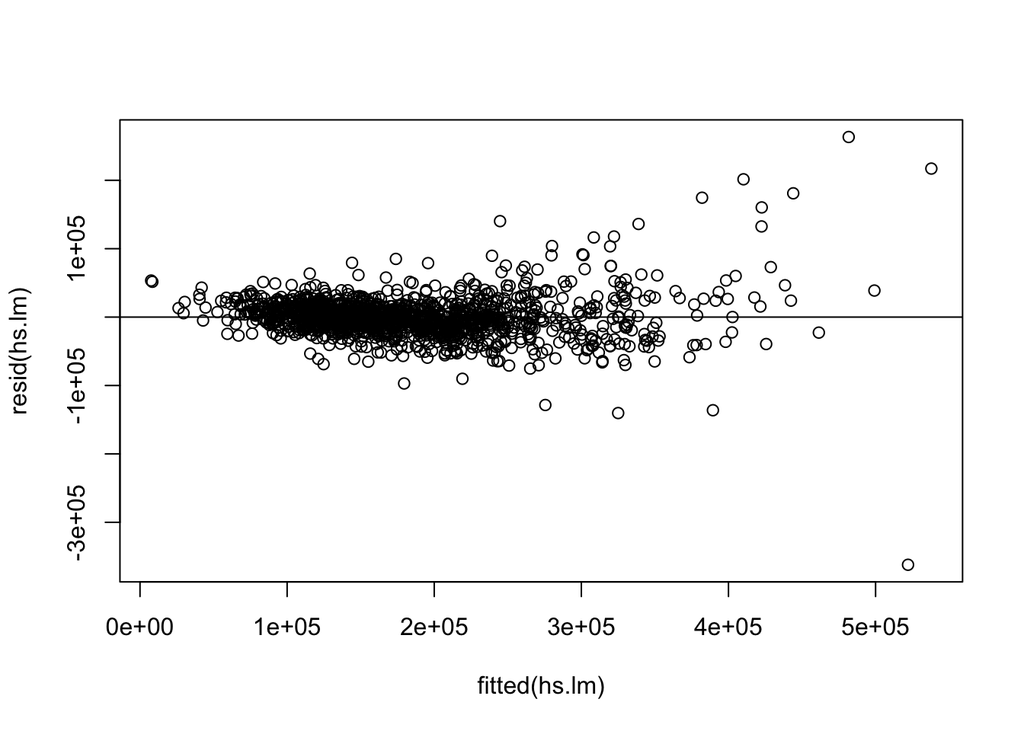

```r
plot(fitted(hs.lm), resid(hs.lm))
abline(h = 0)
```

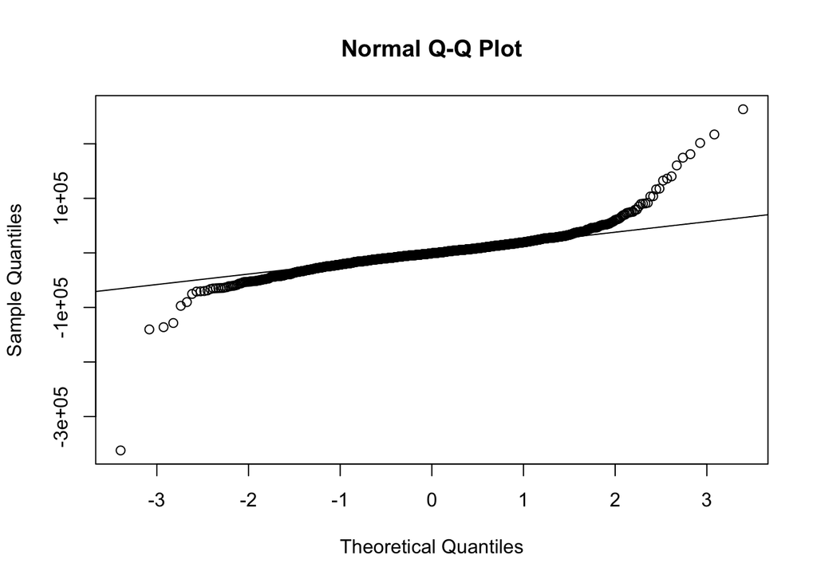

```r
qqnorm(resid(hs.lm))
qqline(resid(hs.lm))
```

**Predicting Response**

```r
df.test <- read.csv("https://raw.githubusercontent.com/PriyaShaji/Data605/master/week%2016/test.csv")

tst <- df.test[,(names(df.test) %in% c("MSSubClass", "MSZoning", "LotFrontage", "LotArea", "LotShape", "LandContour", "LotConfig", "LandSlope", "Neighborhood", "Condition1", "Condition2", "BldgType", "HouseStyle", "OverallQual", "OverallCond", "Exterior1st", "Exterior2nd", "ExterQual", "ExterCond", "Foundation", "HeatingQC", "CentralAir", "GrLivArea", "TotRmsAbvGrd", "GarageArea"))]

# Impute missing data
mean_LotFrontage <- as.integer(summary(tst$LotFrontage)["Mean"])
tst$LotFrontage <- replace(tst$LotFrontage, is.na(tst$LotFrontage), mean_LotFrontage)
mean_GarageArea <- as.integer(summary(tst$GarageArea)["Mean"])
tst$GarageArea <- replace(tst$GarageArea, is.na(tst$GarageArea), mean_GarageArea)

# Derive/Calculate additional features
tst$AgeSold <- df.test$YrSold - df.test$YearBuilt + 1
tst$AgeRemod <- df.test$YrSold - df.test$YearRemodAdd + 1

# Rescale numeric data
# Use Standardization: Subtract the mean and divide by variance
#   This way the features are centered around zero and have variance one
tst$GrLivArea <- standardScaler(tst$GrLivArea)
tst$GarageArea <- standardScaler(tst$GarageArea)
tst$AgeSold <- standardScaler(tst$AgeSold)
tst$AgeRemod <- standardScaler(tst$AgeRemod)

# Predicting the House Prices
hs.pd <- data.frame(
  Id = seq(nrow(trn) + 1, length.out = nrow(tst)),
  SalePrice = predict(hs.lm, newdata = tst)
)
head(hs.pd)
```

|  | Id | SalePrice |
| --- | --- | --- |
| 1 | 1461 | 113017.6 |
| 2 | 1462 | 160456.4 |
| 3 | 1463 | 167846.7 |
| 4 | 1464 | 182056.0 |
| 5 | 1465 | 246980.3 |
| 6 | 1466 | 177207.0 |

```r
write.csv(hs.pd, file = "/Users/priyashaji/Documents/cunymsds/Fall19/data 605/week 16/prediction.csv", quote = FALSE, row.names = FALSE)

summary(hs.pd$SalePrice)
```

```
##    Min. 1st Qu.  Median    Mean 3rd Qu.    Max.
##   -3935  128784  165085  180770  218226  572421
```

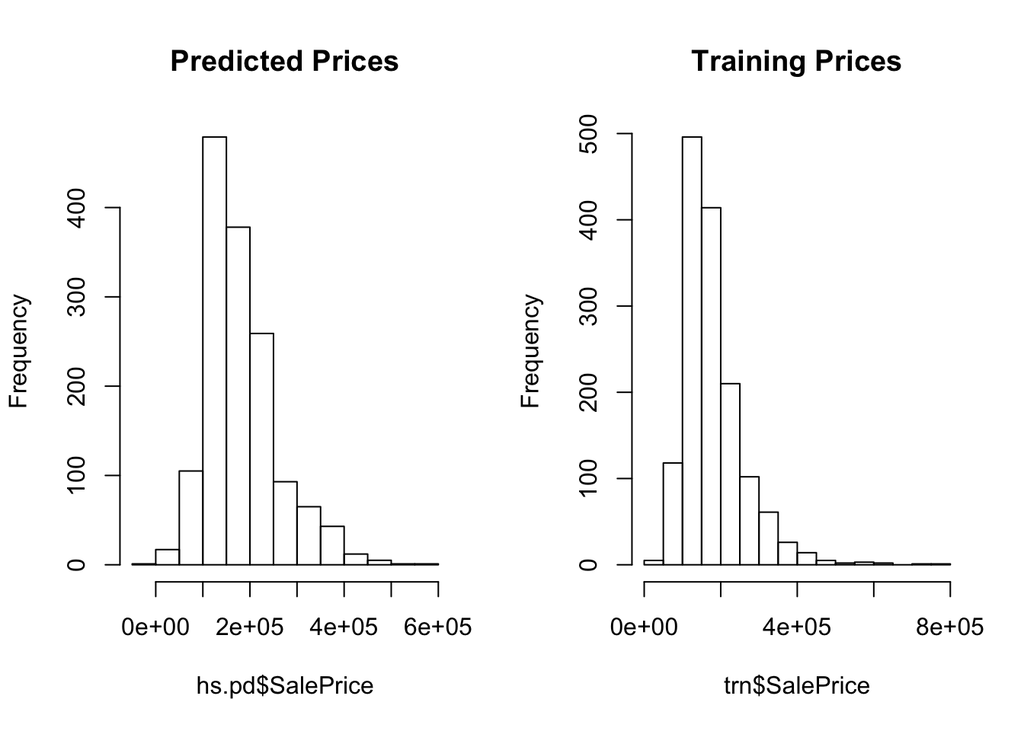

```r
par(mfrow = c(1, 2))
hist(hs.pd$SalePrice, main = "Predicted Prices")
hist(trn$SalePrice, main = "Training Prices")
```

Kaggle.com Username: shajipriya https://www.kaggle.com/shajipriya

Kaggle Score: 0.42341